# kickstarter

```python
import pandas as pd
from pandas import DataFrame
import matplotlib.pyplot as plot
from matplotlib import colors
from matplotlib.ticker import PercentFormatter
import numpy as np
import seaborn as seaBorn
from scipy.stats import skew
%matplotlib inline
from scipy import stats
```

```python
df = pd.read_csv('/Users/kritik/MyStuff/notebooks/GA/kickstarter/DSI_kickstarterscrape_dataset.csv', sep=',', engine='python')
```

```python
df.columns
```

```
Index(['project id', 'name', 'url', 'category', 'subcategory', 'location',
       'status', 'goal', 'pledged', 'funded percentage', 'backers',
       'funded date', 'levels', 'reward levels', 'updates', 'comments',
       'duration'],
      dtype='object')
```

```python
df.dtypes
```

```
project id             int64
name                  object
url                   object
category              object
subcategory           object
location              object
status                object
goal                 float64
pledged              float64
funded percentage    float64
backers                int64
funded date           object
levels                 int64
reward levels         object
updates                int64
comments               int64
duration             float64
dtype: object
```

```python
df['pledged'].mean(axis=0)
```

```
4980.749678963979
```

```python
df['backers'].mean(axis=0)
```

```
69.97319233196248
```

```python
df['pledged'].sum(axis=0)
```

```
228840544.0
```

```python
print(df)
```

```
       project id                                               name  \
0           39409                              WHILE THE TREES SLEEP
1          126581               Educational Online Trading Card Game
2          138119                                              STRUM
3          237090  GETTING OVER - One son's search to finally kno...
4          246101  The Launch of FlyeGrlRoyalty &quot;The New Nam...
...           ...                                                ...
45952  2147336747                                  The Dance Project
45953  2147346811  new album from J-Sw!ft The Adventures of Negro...
45954  2147367534                                      ELIZABETH REX
45955  2147369705                     Dragon Keepers IV Book Project
45956  2147460119                                 Moments of Insight

                                                     url      category  \
0      http://www.kickstarter.com/projects/emiliesaba...  Film & Video
```

[output cut: 64 more lines]

```python
actual_df = df
print(actual_df)
```

```
       project id                                               name  \
0           39409                              WHILE THE TREES SLEEP
1          126581               Educational Online Trading Card Game
2          138119                                              STRUM
3          237090  GETTING OVER - One son's search to finally kno...
4          246101  The Launch of FlyeGrlRoyalty &quot;The New Nam...
...           ...                                                ...
45952  2147336747                                  The Dance Project
45953  2147346811  new album from J-Sw!ft The Adventures of Negro...
45954  2147367534                                      ELIZABETH REX
45955  2147369705                     Dragon Keepers IV Book Project
45956  2147460119                                 Moments of Insight

                                                     url      category  \
0      http://www.kickstarter.com/projects/emiliesaba...  Film & Video
```

[output cut: 64 more lines]

```python
print(df.shape)
```

```
(45957, 17)
```

```python
?df.sum(axis=0)
```

```
Object `df.sum(axis=0)` not found.
```

```python
df.isnull().sum()
```

```
project id              0
name                    0
url                     0
category                0
subcategory             0
location             1322
status                  0
goal                    0
pledged                12
funded percentage       0
backers                 0
funded date             0
levels                  0
reward levels          59
updates                 0
comments                0
duration                0
dtype: int64
```

```python
df.category.value_counts()
```

```
Film &amp; Video    13053
Music               10913
Publishing           4770
Art                  3992
Theater              2492
Design               1768
Games                1738
Photography          1514
Food                 1439
Fashion              1136
Comics               1072
Technology            811
Dance                 761
Film & Video          498
Name: category, dtype: int64
```

```python
df.subcategory.value_counts()
```

```
Documentary               4012
Short Film                3942
Music                     3243
Film &amp; Video          2495
Theater                   2492
Indie Rock                1939
Rock                      1791
Narrative Film            1554
Photography               1514
Food                      1439
Fashion                   1136
Webseries                 1122
Fiction                   1099
Art                       1076
Comics                    1072
Nonfiction                1062
Product Design            1053
Video Games                911
Country &amp; Folk         808
Dance                      761
Pop                        746
Publishing                 673
Children's Book            653
Public Art                 564
Painting                   518
Performance Art            506
Classical Music            482
Hip-Hop                    477
Jazz                       447
Mixed Media                444
Board &amp; Card Games     442
Journalism                 431
World Music                428
Animation                  426
Technology                 372
Sculpture                  356
Art Book                   339
Electronic Music           302
Periodical                 291
Design                     285
Games                      274
Crafts                     255
Open Software              254
Country & Folk             250
Poetry                     222
Illustration               206
Open Hardware              185
Conceptual Art             178
Graphic Design             175
Digital Art                144
Board & Card Games         111
Name: subcategory, dtype: int64
```

```python
print(len(df.category.unique()))
print(len(df.subcategory.unique()))
```

```
14
51
```

```python
print(np.random.seed(0))
```

```
None
```

```python
print(np.random.seed(0))
```

```
None
```

```python
perm = np.random.permutation(10)
print(perm)
```

```
[2 8 4 9 1 6 7 3 0 5]
```

```python
perm = np.random.permutation(10)
print(perm)
```

```
[3 5 1 2 9 8 0 6 7 4]
```

```python
?data.plot
```

```
Object `data.plot` not found.
```

```python
org_df = df
```

```python
#sorted_backers_df = df.sort_values(by=['backers'], inplace=True)
```

```python
print(org_df)
```

[output not shown]

[output cut: 64 more lines]

```python
df_encoded = pd.get_dummies(df.drop(labels=['project id', 'name', 'url', 'goal', 'location',
                                            'subcategory', 'status', 'funded percentage', 'pledged',
                                            'duration', 'updates', 'comments', 'levels' , 'reward levels'], axis=1),
                            columns=['category','backers'])
```

```python
print(df_encoded)
```

```
                           funded date  category_Art  category_Comics  \
0      Fri, 19 Aug 2011 19:28:17 -0000             0                0
1      Mon, 02 Aug 2010 03:59:00 -0000             0                0
2      Fri, 08 Jun 2012 00:00:31 -0000             0                0
3      Sun, 08 Apr 2012 02:14:00 -0000             0                0
4      Wed, 01 Jun 2011 15:25:39 -0000             0                0
...                                ...           ...              ...
45952  Fri, 30 Mar 2012 13:57:00 -0000             0                0
45953  Sun, 22 Apr 2012 02:12:10 -0000             0                0
45954  Mon, 16 Jan 2012 05:00:00 -0000             0                0
45955  Sat, 19 May 2012 19:44:47 -0000             0                0
45956  Thu, 04 Aug 2011 04:30:00 -0000             1                0

       category_Dance  category_Design  category_Fashion  \
0                   0                0                 0
```

[output cut: 64 more lines]

```python
backers_data=df['backers']
numpy_backers = backers_data.to_numpy()
```

```python
print(numpy_backers)
```

```
[66  2  3 ... 58 11 53]
```

```python
print(len(numpy_backers))
```

```
45957
```

```python
print(numpy_backers.mean(),numpy_backers.std())
```

```
69.97319233196248 688.6209867190622
```

```python
hist,bin_edges = np.histogram(numpy_backers, bins=[ 0.,   8714.2, 17428.4, 26142.6, 34856.8, 43571.,  52285.2, 60999.4, 69713.6,
 78427.8])
```

```python
print(hist)
print(bin_edges)
```

```
[45942     9     2     0     1     0     0     2     0]
[    0.   8714.2 17428.4 26142.6 34856.8 43571.  52285.2 60999.4 69713.6
 78427.8]
```

```python
print(bin_edges[:-1])
```

```
[    0.   8714.2 17428.4 26142.6 34856.8 43571.  52285.2 60999.4 69713.6]
```

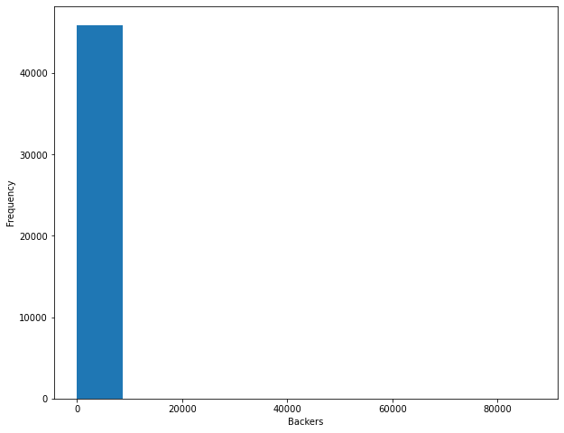

```python
plot.figure(figsize=[10,8])
plot.xlabel('Backers')
plot.ylabel('Frequency')
plot.hist(numpy_backers)
```

```python
pd.DataFrame(actual_df['backers']).describe()
```

|  | backers |
| --- | --- |
| count | 45957.000000 |
| mean | 69.973192 |
| std | 688.628479 |
| min | 0.000000 |
| 25% | 5.000000 |
| 50% | 23.000000 |
| 75% | 59.000000 |
| max | 87142.000000 |

The backer's data from above has been shown in histogram in similar due to lot of ourliers. The backer stats shown, there are only 59 backers at most until 75th percentile. I shall consider to see how they spead acrss using box plot.

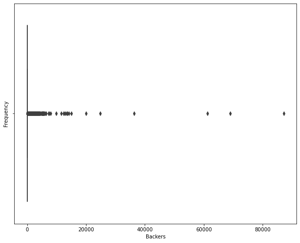

```python
plot.figure(figsize=[10,8])
plot.xlabel('Backers')
plot.ylabel('Frequency')
seaBorn.boxplot(x=numpy_backers)
```

```python
mean = np.mean(numpy_backers, axis=0)
sd = np.std(numpy_backers, axis=0)
print(type(backers_data))
backers_list= df['backers'].tolist()
print(type(backers_list))
backers_final_list = [x for x in backers_list if (x > mean - 2 * sd)]
backers_final_list = [x for x in backers_final_list if (x < mean + 2 * sd)]
backers_filtered_df = DataFrame (backers_final_list,columns=['filtered_backers'])
print(backers_filtered_df)
```

```
<class 'pandas.core.series.Series'>
<class 'list'>
       filtered_backers
0                    66
1                     2
2                     3
3                   100
4                     0
...                 ...
45787                13
45788                 2
45789                58
45790                11
45791                53

[45792 rows x 1 columns]
```

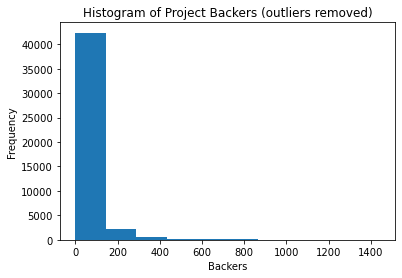

```python
# Histogram of filtered 'backers' column
plot.hist(backers_filtered_df['filtered_backers'])
plot.xlabel('Backers')
plot.ylabel('Frequency')
plot.title('Histogram of Project Backers (outliers removed)')
plot.show()
```

```python
backers_filtered_df = df[((df.backers - df.backers.mean()) / df.backers.std()).abs() < .085]
backers_filtered_df['backers'].describe()
```

```
count    24979.000000
mean        46.829016
std         29.133568
min         12.000000
25%         23.000000
50%         39.000000
75%         65.000000
max        128.000000
Name: backers, dtype: float64
```

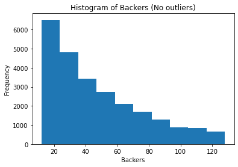

```python
# Histogram of filtered 'backers' column
plot.hist(backers_filtered_df['backers'])
plot.xlabel('Backers')
plot.ylabel('Frequency')
plot.title('Histogram of Backers (No outliers)')
plot.show()
```

```python
# k = z-score, p = p-value
k,p = stats.mstats.normaltest(numpy_backers)
if p < 0.05:
 print('P-value =', p, '\nZ-score =', k, '\nDistribution is not normal.')
else:
 print('P-value =', p, '\nZ-score =', k, '\nDistribution is normal')
```

```
P-value = [0.]
Z-score = [174771.50014415907]
Distribution is not normal.
```

## With above histogram and below distribution plot, we can easily conclude that backers distribution is strongly positive skewed which is right skewed and left leaning and it is not normally distributed.

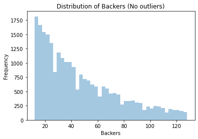

```python
seaBorn.distplot(backers_filtered_df['backers'], kde=False)
plot.xlabel('Backers')
plot.ylabel('Frequency')
plot.title('Distribution of Backers (No outliers)')
plot.show()
```

## Is the ‘duration’ variable normally distributed ?

```python
df.duration.describe()
```

```
count    45957.000000
mean        39.995547
std         17.414458
min          1.000000
25%         30.000000
50%         32.000000
75%         48.390000
max         91.960000
Name: duration, dtype: float64
```

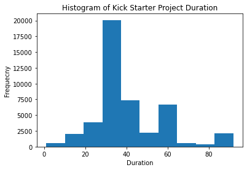

```python
plot.hist(df['duration'])
plot.xlabel('Duration')
plot.ylabel('Frequecny')
plot.title('Histogram of Kick Starter Project Duration')
plot.show()
```

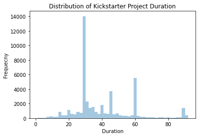

```python
# Plot distribution plot of 'duration' column
seaBorn.distplot(df['duration'], kde=False)
plot.xlabel('Duration')
plot.ylabel('Frequecny')
plot.title('Distribution of Kickstarter Project Duration')
plot.show()
```

```python
nparray_duration = np.array(df['duration'])
k,p = stats.mstats.normaltest(nparray_duration)
if p < 0.05:
 print('P-value =', p, '\nZ-score =', k, '\n Continuous Variable is NOT distributed normally.')
else:
 print('P-value =', p, '\nZ-score =', k, '\n Continuous Variable is distributed normally.')
```

```
P-value = 0.0
Z-score = 6985.5754355009585
 Continuous Variable is NOT distributed normally.
```

## Duration Variable is not normally distributed.

# Part 2: Qualitative Analysis

Create a presentation using Google Slides (max. 5 slides) using the data above (and additional data from those tables) that make clear recommendations on how people can create a successful Kickstarter campaign.

```python
df.status.unique()
```

```
array(['successful', 'failed', 'live', 'canceled', 'suspended'],
      dtype=object)
```

I'm thinking of generalising the status value in to a boolean value to compare this continuous variable more predominently with other attributes.

Let's map projects with status as ['Cancled','failed','suspended'] to 'False' and 'Succesful' to 'True'. Ignore, Live for now as that doesn't hold much importance in this analysis.

```python
status_var = {'successful': True, 'failed': False, 'suspended': False, 'canceled':False}
df['status_bool_var'] = df['status'].map(status_var)
```

## What's the best length of time to run a campaign?

As we are talking about time, we shall consider the duration that led to status of a campaign

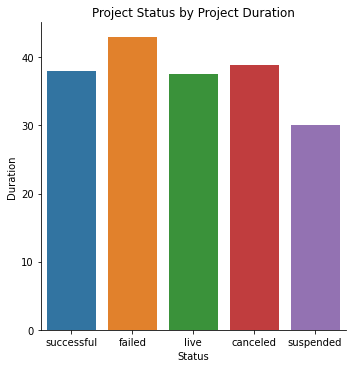

```python
# Plot showing rates of success by duration
seaBorn.factorplot(x='status', y='duration', data=df, kind='bar', ci=None)
plot.xlabel('Status')
plot.ylabel('Duration')
plot.title('Project Status by Project Duration')
plot.show()
```

## Now , let me generalise the status by 'Status bool Var'

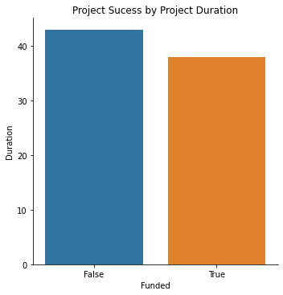

```python
# Plot showing rates of success by duration
seaBorn.factorplot(y='duration', x='status_bool_var', data=df, kind='bar', ci=None)
plot.xlabel('Funded')
plot.ylabel('Duration')
plot.title('Project Sucess by Project Duration')
plot.show()
```

## What's the ideal pledge goal?

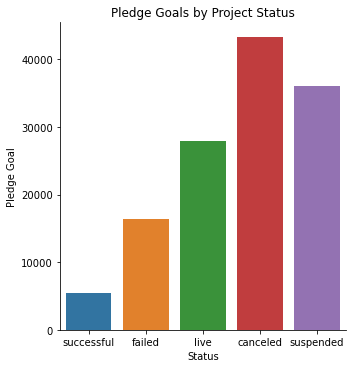

```python
seaBorn.factorplot(x='status', y='goal', data=df, kind='bar', ci=None)
plot.xlabel('Status')
plot.ylabel('Pledge Goal')
plot.title('Pledge Goals by Project Status')
plot.show()
```

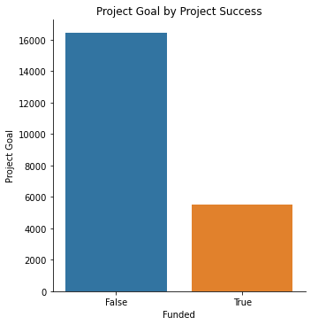

```python
# Plot showing rates of success by duration
seaBorn.factorplot(x='status_bool_var', y='goal', data=df, kind='bar', ci=None)
plot.xlabel('Funded')
plot.ylabel('Project Goal')
plot.title('Project Goal by Project Success')
plot.show()
```

### Ah! Above plot shows that projects that are funded successfuly are having less pledge goal. It can be infered that the more is the pledge goal the less are the chances of gettng funded

## What type of projects would be most successful at getting funded?

```python
# Print categories
df['category'].unique().tolist()
```

```
['Film & Video',
 'Games',
 'Fashion',
 'Music',
 'Art',
 'Technology',
 'Dance',
 'Publishing',
 'Theater',
 'Comics',
 'Design',
 'Photography',
 'Food',
 'Film &amp; Video']
```

#### looks like the category "Film & Video" is for "Film & Video". let me fix it

```python
df['category'] = df['category'].replace(['Film &amp; Video'], 'Film & Video')
df['category'].unique().tolist()
```

```
['Film & Video',
 'Games',
 'Fashion',
 'Music',
 'Art',
 'Technology',
 'Dance',
 'Publishing',
 'Theater',
 'Comics',
 'Design',
 'Photography',
 'Food']
```

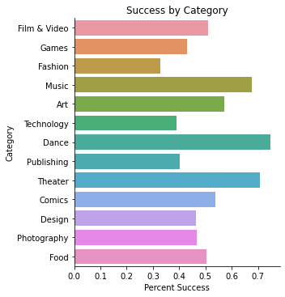

```python
seaBorn.factorplot(y='category', x='status_bool_var', data=df, kind='bar', ci=None)
plot.xlabel('Percent Success')
plot.ylabel('Category')
plot.title('Success by Category')
plot.show()
```

#### The categories that are funded successfully are Music, Dance and Theater. Eveerything else are least funded. Fashion, Technology anf Publshing are least funded.

## Is there an ideal month/day/time to launch a campaign?

```python
?df['funded date'].to_string
```

```
Object `df['funded date'].to_string` not found.
```

```python
print(df.dtypes)
```

```
project id             int64
name                  object
url                   object
category              object
subcategory           object
location              object
status                object
goal                 float64
pledged              float64
funded percentage    float64
backers                int64
funded date           object
levels                 int64
reward levels         object
updates                int64
comments               int64
duration             float64
dtype: object
```

```python
#df['funded date'] = df['funded date'].astype('str')
```

```python
df['funded date'] = df["funded date"].astype("|S")
```

```python
print(df.dtypes)
```

```
project id             int64
name                  object
url                   object
category              object
subcategory           object
location              object
status                object
goal                 float64
pledged              float64
funded percentage    float64
backers                int64
funded date           object
levels                 int64
reward levels         object
updates                int64
comments               int64
duration             float64
dtype: object
```

```python
#df['funded date'] = str(df['funded date'])
```

```python
import datetime as dt

# print(df.dtypes)

# time = "Mon, 02 Aug 2010 03:59:00 -0000"

# print("Type of str time", type(time))

# lambda_month = (lambda x: dt.datetime.strptime(x, '%a, %d %b %Y %X -%f').strftime('%B'))

# print(lambda_month(time))

# lambda_day = (lambda x: dt.datetime.strptime(x, '%a, %d %b %Y %X -%f').strftime('%a'))

# print(lambda_day(time))

# Apply above lamda to data frame and create two columns for month and day.

# convert date_type to string to ease calculation

# df['funded date'] = df.to_string(columns = ['funded date'])
# print(df.dtypes)

# print("Date column",df['funded date'] )


# df['funded date']= pd.to_datetime(df['funded date'])
# df['month'] = df['funded date'].dt.to_period('M')
# print(df['month'])

# # print(df['funded date'].astype('datetime64[M]'))

df['funded_months'] = df['funded date'].apply(lambda x: dt.datetime.strptime(x.decode('ascii').strip(), '%a, %d %b %Y %X -%f').strftime('%B'))


df['funded_days'] = df['funded date'].apply(lambda x: dt.datetime.strptime(x.decode('ascii').strip(), '%a, %d %b %Y %X -%f').strftime('%a'))
```

```python
print(df['funded_months'] )
```

```
0         August
1         August
2           June
3          April
4           June
          ...
45952      March
45953      April
45954    January
45955        May
45956     August
Name: funded_months, Length: 45957, dtype: object
```

```python
print(df['funded_days'])
```

```
0        Fri
1        Mon
2        Fri
3        Sun
4        Wed
        ...
45952    Fri
45953    Sun
45954    Mon
45955    Sat
45956    Thu
Name: funded_days, Length: 45957, dtype: object
```

## Is there an ideal month/day/time to launch a campaign?

```python
df['funded date'] = df["funded date"].astype("|S")

df['funded_months'] = df['funded date'].apply(lambda x: dt.datetime.strptime(x.decode('ascii').strip(), '%a, %d %b %Y %X -%f').strftime('%B'))

df['funded_days'] = df['funded date'].apply(lambda x: dt.datetime.strptime(x.decode('ascii').strip(), '%a, %d %b %Y %X -%f').strftime('%a'))
```

[figure not shown]

```python
seaBorn.factorplot(y='funded_days', x='status_bool_var', data=df, kind='bar', ci=None)
plot.xlabel('Project Succesful Percent')
plot.ylabel('Funding Day')
plot.title('Project Success By Funding Dat')
plot.show()
```

#### Per above graph, it was clear that there is no much to interpret project's success based on day of the funding.

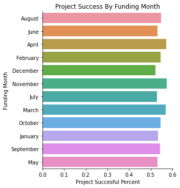

```python
seaBorn.factorplot(y='funded_months', x='status_bool_var', data=df, kind='bar', ci=None)
plot.xlabel('Project Succesful Percent')
plot.ylabel('Funding Month')
plot.title('Project Success By Funding Month')
plot.show()
```

#### Per above graph, it was clear that there is no much to interpret project's success based on Month of the funding.